# R Notebook

```r
head(phoible)
```

|  | language | genus | fam | phonemes | con | son | obs | vow | monoph | qua | ton | population |
| --- | --- | --- | --- | --- | --- | --- | --- | --- | --- | --- | --- | --- |
| 1 | aal | Biu-Mandara | afas | 36 | 27 | 6 | 21 | 9 | 9 | 9 | 0 | 31000 |
| 2 | aau | Upper Sepik | sepr | 14 | 9 | 5 | 4 | 5 | 5 | 5 | 0 | 7270 |
| 3 | abi | Kwa | ncon | 39 | 21 | 7 | 14 | 18 | 18 | 9 | 0 | 50500 |
| 4 | abt | Middle Sepik | sepr | 24 | 17 | 12 | 5 | 7 | 7 | 6 | 0 | 44000 |
| 5 | ace | Malayic | anes | 55 | 21 | 8 | 13 | 34 | 17 | 10 | 0 | 3500000 |
| 6 | acv | Palaihnihan | hoka | 23 | 17 | 6 | 11 | 6 | 6 | 6 | 0 | 16 |

# Task 1: Indo-European (ieur) vs. Nilo-Saharan (nsah)

- Consider the parallel boxplots of the Indo-European (ieur) and Nilo-Saharan (nsah) language families.

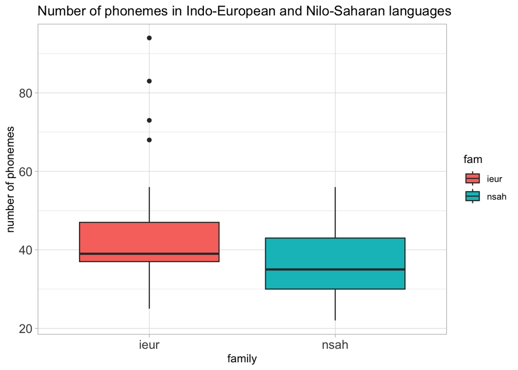

- Answer the following questions:
1. Which distribution has outliers? How many?
2. Which distribution is more compact?
3. Which distribution has the largest range (with and without the outliers)?
4. What is the range of Nilo-Saharan phoneme inventories?
5. Which distribution is negatively skewed?
6. How many languages are in each boxplot?

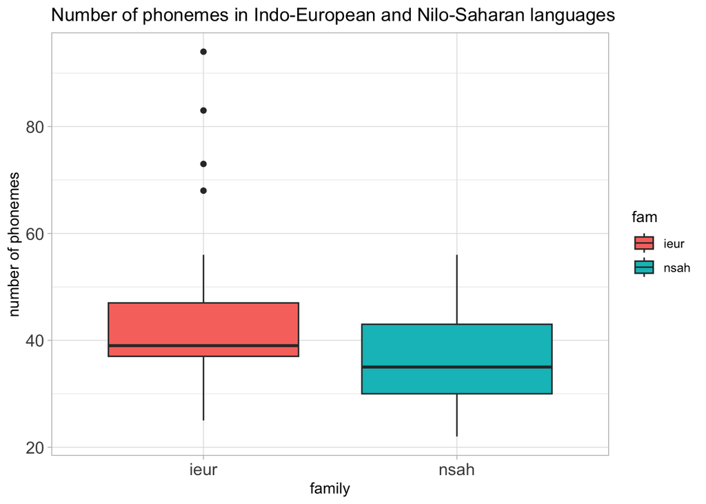

# Task 2

- Consider the parallel boxplots of four language families:

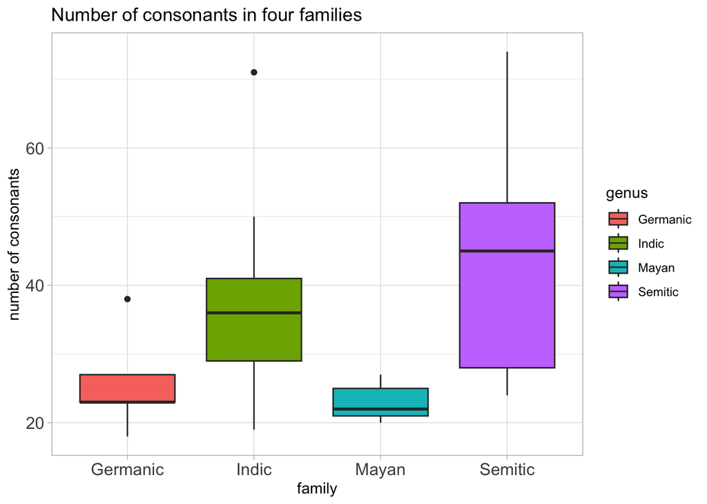

- The data set (number of consonants) for one of the four languages families is this:

| con |
| --- |
| 23 |
| 27 |
| 23 |
| 23 |
| 23 |
| 24 |
| 27 |
| 18 |
| 38 |

- Which boxplot corresponds to this dataset? Discuss, the various aspects of the boxplot which make the identification possible.

## Solutions

- Germanic

  | language | con |
  | --- | --- |
  | deu | 23 |
  | eng | 27 |
  | frr | 23 |
  | isl | 23 |
  | nds | 23 |
  | nld | 24 |
  | nob | 27 |
  | swe | 18 |
  | ydd | 38 |

# Task 3: boxplot vs. density plot

- Consider the parallel boxplots of the number of phonemes in four language families.
- One of the language families is visualized with a density plot. Which one is it?

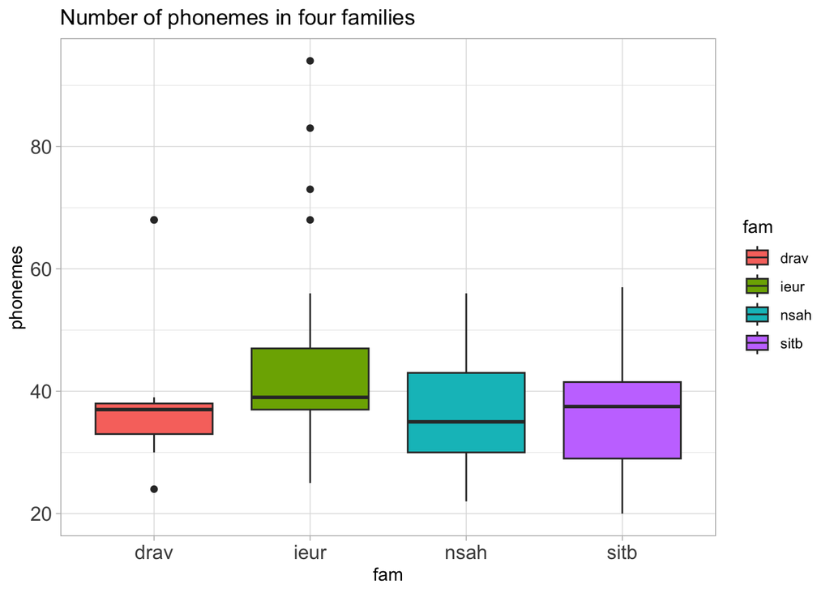

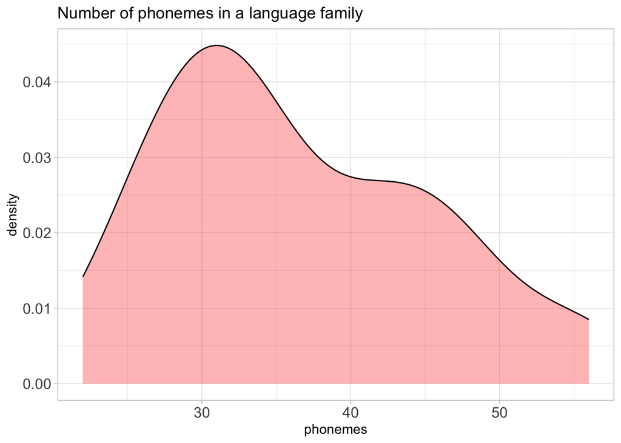

## Solutions

- Nilo-Saharan

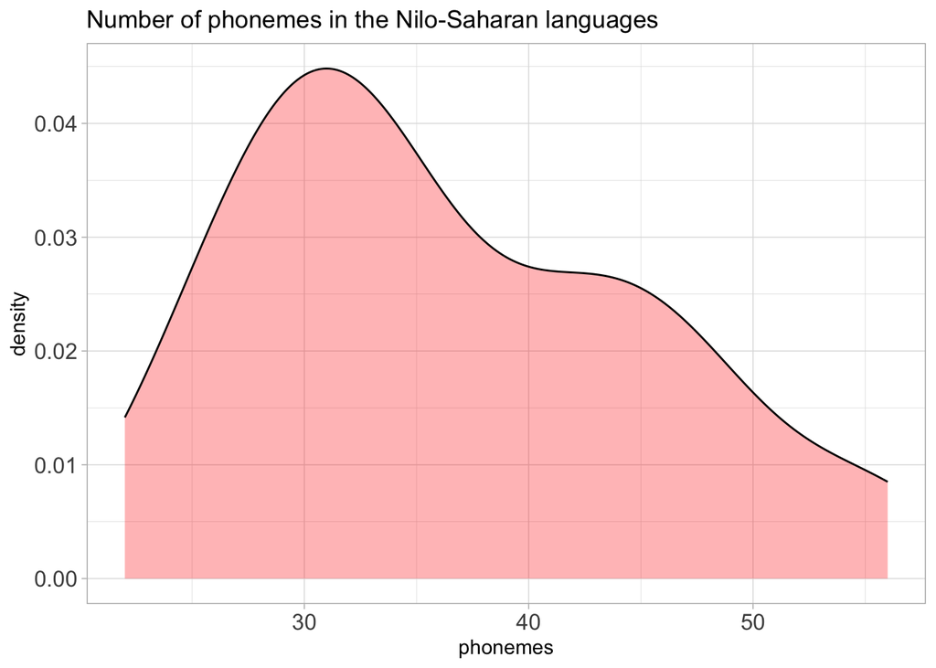

# Task 4: boxplot vs. density plot

- Consider the parallel boxplots of the number of phonemes in four language families.
- Two of the language families are visualized with the density plots. Which oness are they?
- Explain how you can figure it out.

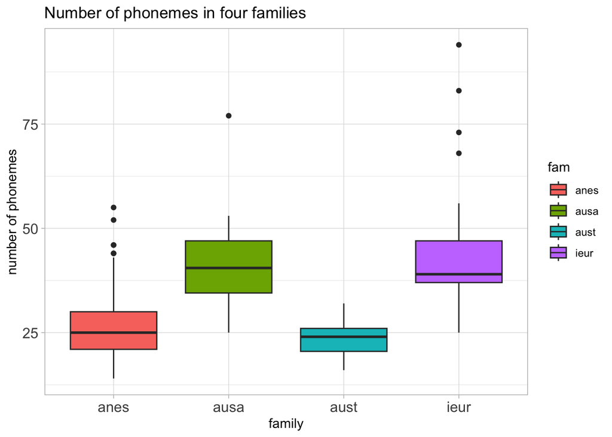

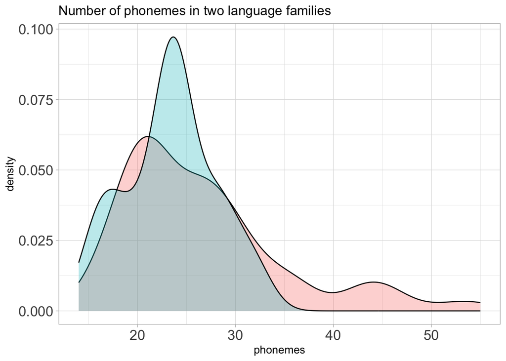

## Solutions

Australian (`aust`) and Austronesian (`anes`)

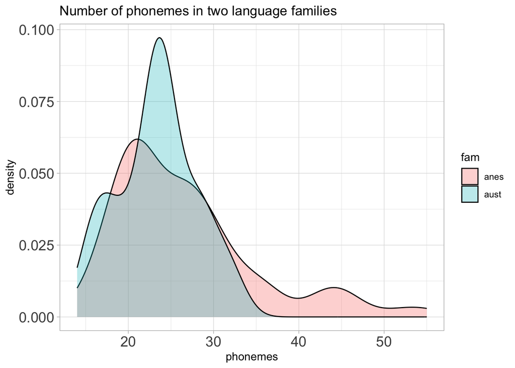

# Task 5: boxplot vs. histogram

- Consider the parallel boxplots of the number of phonemes in four language families.
- Three of the language families are visualized with the histograms. Which one is missing?
- Explain how you can figure it out.

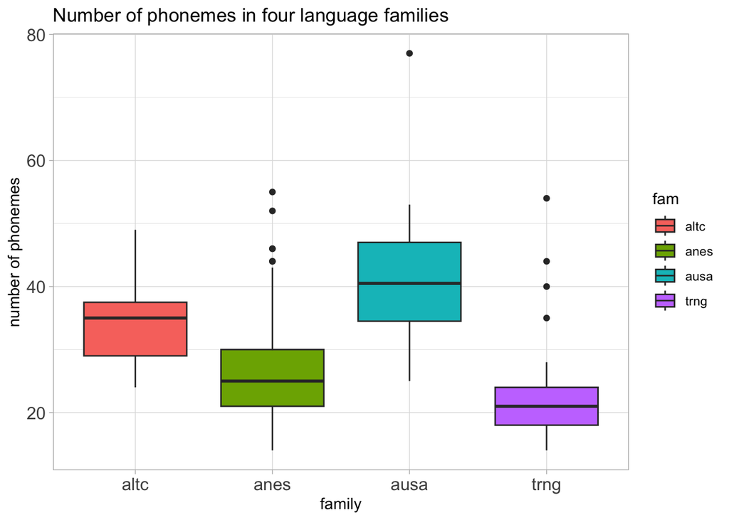

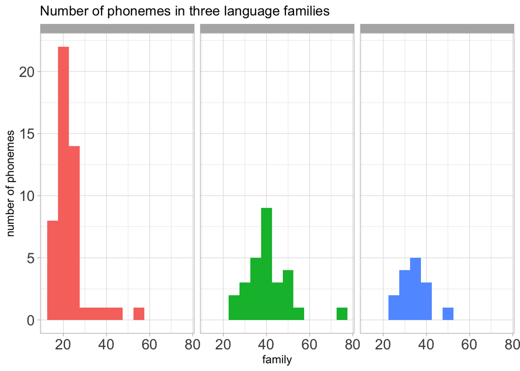

## Solutions

- The missing family is Austronesian (`anes`)

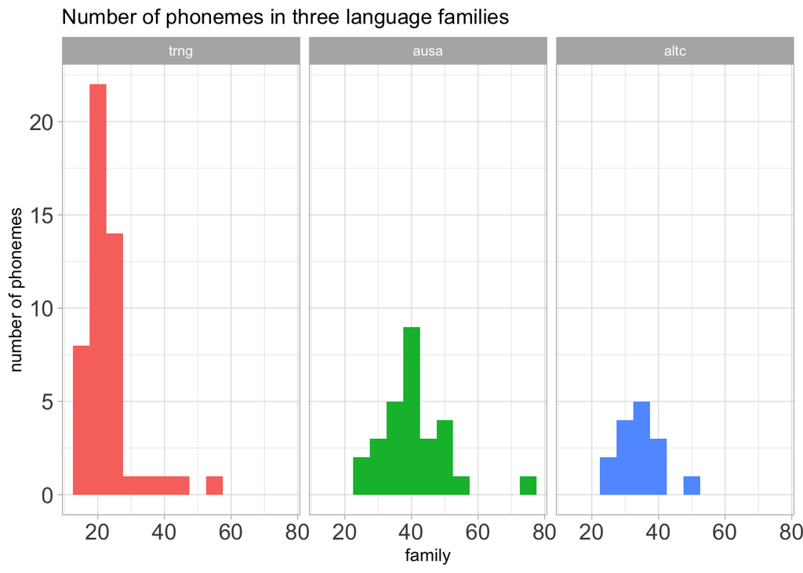

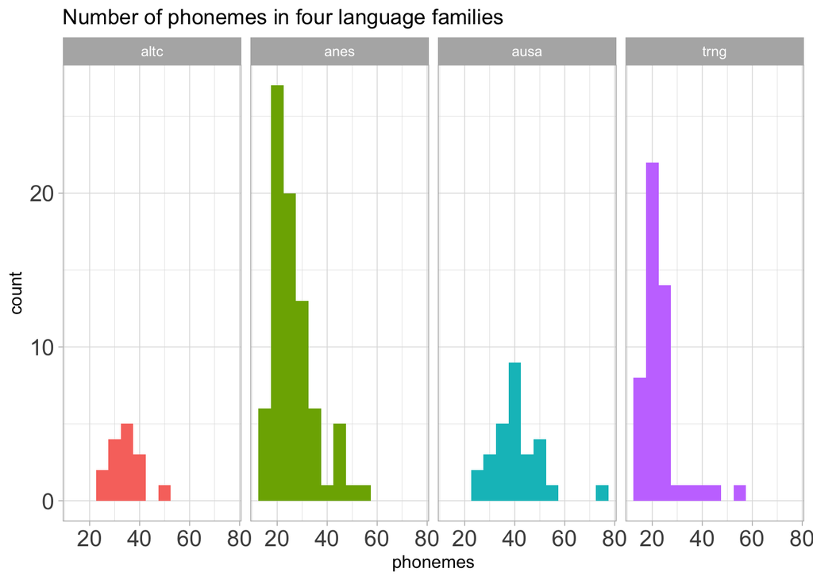